# Assignment2

Author

Derek Walker

```r
library(ggplot2)
library(cowplot)
library("R.utils")
library(dtplyr)
library(dplyr)
library(data.table)
library(leaflet)
library(hrbrthemes)
```

## Part 1

```r
chs_indiv_url <- "https://raw.githubusercontent.com/USCbiostats/data-science-data/master/01_chs/chs_individual.csv"
tmp1 <- "/Users/gazallab/Desktop/PM566/Git/Assignment_2/chs_indiv.csv"
if (!file.exists(tmp1)) {
  download.file(
    url      = chs_indiv_url,
    destfile = tmp1,
    # method   = "libcurl", timeout = 1000 (you may need this option)
  )
}
chs_indiv<- data.table::fread("/Users/gazallab/Desktop/PM566/Git/Assignment_2/chs_indiv.csv")

chs_region_url <- "https://raw.githubusercontent.com/USCbiostats/data-science-data/master/01_chs/chs_regional.csv"
tmp2 <- "/Users/gazallab/Desktop/PM566/Git/Assignment_2/chs_region.csv"
if (!file.exists(tmp2)) {
  download.file(
    url      = chs_region_url,
    destfile = tmp2,
    # method   = "libcurl", timeout = 1000 (you may need this option)
  )
}
chs_reg <- read.csv("/Users/gazallab/Desktop/PM566/Git/Assignment_2/chs_region.csv", header = T)
```

```r
new <- merge(
  # Data
  x     = chs_indiv,
  y     = chs_reg,
  # List of variables to match
  by.x  = "townname",
  by.y  = "townname",
  # Which obs to keep?
  all.x = TRUE,
  all.y = FALSE
  )

nrow(new)==nrow(chs_indiv)
```

```
[1] TRUE
```

```r
colSums(is.na(new))
```

```
     townname           sid          male          race      hispanic
            0             0             0             0             0
       agepft        height        weight           bmi        asthma
           89            89            89            89            31
active_asthma father_asthma mother_asthma        wheeze      hayfever
            0           106            56            71           118
      allergy   educ_parent         smoke          pets      gasstove
           63            64            40             0            33
          fev           fvc          mmef     pm25_mass      pm25_so4
           95            97           106             0             0
     pm25_no3      pm25_nh4       pm25_oc       pm25_ec       pm25_om
            0             0             0             0             0
      pm10_oc       pm10_ec       pm10_tc        formic        acetic
            0             0             0             0             0
          hcl          hno3        o3_max         o3106         o3_24
            0             0             0             0             0
          no2          pm10       no_24hr      pm2_5_fr         iacid
            0             0           100           300             0
        oacid   total_acids           lon           lat
            0             0             0             0
```

```r
newnum <- select_if(new, is.numeric)
```

```r
g<-new %>% group_by(male, hispanic) %>%
  summarise(across(where(is.numeric),~ mean(.x, na.rm = TRUE)))
g$asthma <- round(g$asthma)
g$active_asthma <- round(g$active_asthma)
g$father_asthma <- round(g$father_asthma)
g$mother_asthma <- round(g$mother_asthma)
g$hayfever <- round(g$hayfever)
g$allergy <- round(g$allergy)
g$smoke <- round(g$smoke)
g$pets <- round(g$pets)
g$gasstove <- round(g$gasstove)

new2 <- merge(new, g, by.x=c('male','hispanic'), by.y=c('male','hispanic'), all.x=T)

nvec <- gsub("(\\.x|\\.y)","",names(new2))
nvec <- unique(nvec)
nvec <- nvec[-c(1,2)]

for(n in nvec){
  n.y <- paste0(n,'.y')
  n.x <- paste0(n,'.x')
  new2[[n.x]][is.na(new2[[n.x]])] <- new2[[n.y]][is.na(new2[[n.x]])]
}

colSums(is.na(new2)) #Determine the NAs have been adjusted properly
```

```
           male        hispanic        townname           sid.x            race
              0               0               0               0               0
       agepft.x        height.x        weight.x           bmi.x        asthma.x
              0               0               0               0               0
active_asthma.x father_asthma.x mother_asthma.x        wheeze.x      hayfever.x
              0               0               0               0               0
      allergy.x   educ_parent.x         smoke.x          pets.x      gasstove.x
              0               0               0               0               0
          fev.x           fvc.x          mmef.x     pm25_mass.x      pm25_so4.x
              0               0               0               0               0
     pm25_no3.x      pm25_nh4.x       pm25_oc.x       pm25_ec.x       pm25_om.x
              0               0               0               0               0
      pm10_oc.x       pm10_ec.x       pm10_tc.x        formic.x        acetic.x
              0               0               0               0               0
          hcl.x          hno3.x        o3_max.x         o3106.x         o3_24.x
              0               0               0               0               0
          no2.x          pm10.x       no_24hr.x      pm2_5_fr.x         iacid.x
              0               0               0               0               0
        oacid.x   total_acids.x           lon.x           lat.x           sid.y
              0               0               0               0               0
       agepft.y        height.y        weight.y           bmi.y        asthma.y
              0               0               0               0               0
active_asthma.y father_asthma.y mother_asthma.y        wheeze.y      hayfever.y
              0               0               0               0               0
      allergy.y   educ_parent.y         smoke.y          pets.y      gasstove.y
              0               0               0               0               0
          fev.y           fvc.y          mmef.y     pm25_mass.y      pm25_so4.y
              0               0               0               0               0
     pm25_no3.y      pm25_nh4.y       pm25_oc.y       pm25_ec.y       pm25_om.y
              0               0               0               0               0
      pm10_oc.y       pm10_ec.y       pm10_tc.y        formic.y        acetic.y
              0               0               0               0               0
          hcl.y          hno3.y        o3_max.y         o3106.y         o3_24.y
              0               0               0               0               0
          no2.y          pm10.y       no_24hr.y      pm2_5_fr.y         iacid.y
              0               0               0               0               0
        oacid.y   total_acids.y           lon.y           lat.y
              0               0               0               0
```

```r
new2<- new2[,-c(50:94)]
for ( col in 4:ncol(new2)){
    colnames(new2)[col] <-  sub("\\.x.*", "", colnames(new2)[col])
}
colnames(new2)==colnames(new)#Only returns False in first 5 columns due to reordering
```

```
 [1] FALSE FALSE FALSE FALSE FALSE  TRUE  TRUE  TRUE  TRUE  TRUE  TRUE  TRUE
[13]  TRUE  TRUE  TRUE  TRUE  TRUE  TRUE  TRUE  TRUE  TRUE  TRUE  TRUE  TRUE
[25]  TRUE  TRUE  TRUE  TRUE  TRUE  TRUE  TRUE  TRUE  TRUE  TRUE  TRUE  TRUE
[37]  TRUE  TRUE  TRUE  TRUE  TRUE  TRUE  TRUE  TRUE  TRUE  TRUE  TRUE  TRUE
[49]  TRUE
```

```r
#Let's use a more appropriate identifier for our dataset
chs <-new2
```

```r
chs<-chs[!(is.na(bmi))]
chs$obesity_lvl <- ifelse(chs$bmi<14,"Underweight",
                  ifelse(chs$bmi>=14 & chs$bmi<22, "Normal",
                  ifelse(chs$bmi>=22 & chs$bmi<24, "Overweight",
                  ifelse(chs$bmi>=24, "Obese", NA))))

chs %>% group_by(obesity_lvl) %>% summarise(minbmi= min(bmi), maxbmi=max(bmi),nobs = n())
```

```
# A tibble: 4 × 4
  obesity_lvl minbmi maxbmi  nobs
  <chr>        <dbl>  <dbl> <int>
1 Normal        14.0   22.0   975
2 Obese         24.0   41.3   103
3 Overweight    22.0   24.0    87
4 Underweight   11.3   14.0    35
```

```r
#table(new$obesity_lvl) - comparison
chs$smoke_gas_exposure <- ifelse(chs$smoke ==0 & chs$gasstove==0, "Neither",
                      ifelse(chs$smoke==0 & chs$gasstove==1, "Gas",
                      ifelse(chs$smoke==1 & chs$gasstove==0, "Smoke",
                      ifelse(chs$smoke==1 & chs$gasstove==1, "Both",NA))))

#Townname
chs %>% group_by(townname) %>%
  summarise(meanfev = mean(fev, na.rm=T),
            sdfev = sd(fev, na.rm=T))
```

```
# A tibble: 12 × 3
   townname      meanfev sdfev
   <chr>           <dbl> <dbl>
 1 Alpine          2087.  291.
 2 Atascadero      2076.  324.
 3 Lake Elsinore   2039.  304.
 4 Lake Gregory    2085.  320.
 5 Lancaster       2003.  317.
 6 Lompoc          2034.  351.
 7 Long Beach      1986.  319.
 8 Mira Loma       1985.  325.
 9 Riverside       1990.  278.
10 San Dimas       2027.  319.
11 Santa Maria     2026.  312.
12 Upland          2024.  343.
```

```r
#Sex
chs %>% group_by(male) %>%
  summarise(meanfev = mean(fev, na.rm=T),
            sdfev = sd(fev, na.rm=T))
```

```
# A tibble: 2 × 3
   male meanfev sdfev
  <int>   <dbl> <dbl>
1     0   1959.  312.
2     1   2104.  308.
```

```r
#Obesity Level
chs %>% group_by(obesity_lvl) %>%
  summarise(meanfev = mean(fev, na.rm=T),
            sdfev = sd(fev, na.rm=T))
```

```
# A tibble: 4 × 3
  obesity_lvl meanfev sdfev
  <chr>         <dbl> <dbl>
1 Normal        2000.  295.
2 Obese         2266.  325.
3 Overweight    2224.  317.
4 Underweight   1698.  303.
```

```r
#Smoke_gas_exposure
chs %>% group_by(smoke_gas_exposure) %>%
  summarise(meanfev = mean(fev, na.rm=T),
            sdfev = sd(fev, na.rm=T))
```

```
# A tibble: 4 × 3
  smoke_gas_exposure meanfev sdfev
  <chr>                <dbl> <dbl>
1 Both                 2025.  301.
2 Gas                  2023.  319.
3 Neither              2057.  329.
4 Smoke                2056.  296.
```

## Part 2

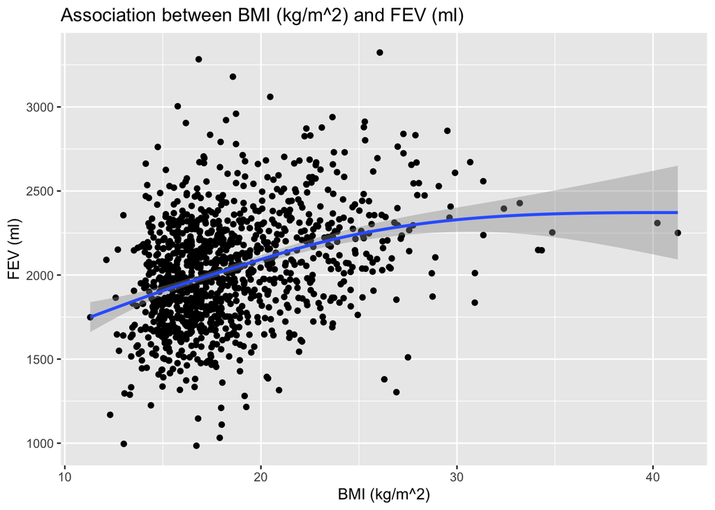

```r
#BMI vs FEV
ggplot(data = chs, mapping = aes(x = bmi, y = fev)) +
  geom_point() + geom_smooth(mapping = aes(x = bmi, y = fev)) +
  labs(x  = "BMI (kg/m^2)", y = "FEV (ml)") + ggtitle("Association between BMI (kg/m^2) and FEV (ml)")
```

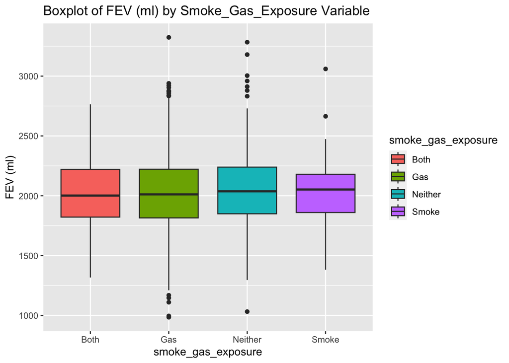

```r
scatterplot <- ggplot(data = chs) + geom_point(mapping = aes(x = smoke_gas_exposure, y = fev))


#Smokegas vs FEV
chs %>% ggplot()+
  geom_boxplot(mapping=aes(x=smoke_gas_exposure, y=fev, fill=smoke_gas_exposure)) +  labs(y = "FEV (ml)")+ ggtitle("Boxplot of FEV (ml) by Smoke_Gas_Exposure Variable")
```

```r
chs %>% group_by(smoke_gas_exposure) %>%
  summarise(meanfev = mean(fev, na.rm = T),
            sdfev = sd(fev, na.rm=T),
            n =n()
            )
```

```
# A tibble: 4 × 4
  smoke_gas_exposure meanfev sdfev     n
  <chr>                <dbl> <dbl> <int>
1 Both                 2025.  301.   154
2 Gas                  2023.  319.   791
3 Neither              2057.  329.   219
4 Smoke                2056.  296.    36
```

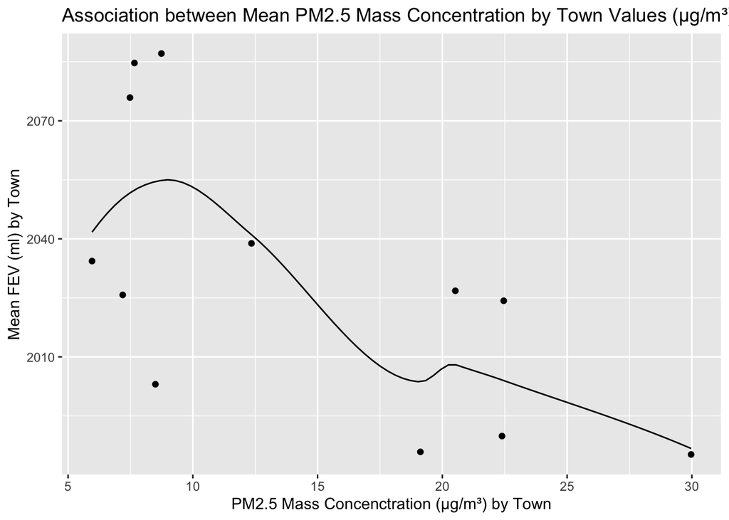

```r
#PM25 vs FEV
test <- chs %>% group_by(pm25_mass) %>%
  summarise(meanfev = mean(fev, na.rm = T))

meanfev=mean(chs$fev,na.rm=T)
ggplot(test, aes(x=pm25_mass, y=meanfev)) +geom_point() + stat_smooth(method='loess', col='black', size=0.5, se=F)+ labs(x  = "PM2.5 Mass Concenctration (µg/m³) by Town", y = "Mean FEV (ml) by Town") +ggtitle("Association between Mean PM2.5 Mass Concentration by Town Values (µg/m³) and Mean FEV (ml)")
```

Evaluation:

BMI vs FEV: In general as the BMI increases the FEV variable increases as well indicating there is a positive association.

Smoke_gas_exp vs FEV: In general there does not appear to be much an association between the smoke_gas_exp at each level and FEV. Though when neither smoke nor gas variables were present in the household the FEV was on average higher than if either or both were present.

PM2.5 vs FEV: There appears to be a negative association between Mean PM2.5 concentration by town and Mean FEV by town. We should expect to see this given certain pollutants are biologically linked with a negative effect on lung function.

## Part 3

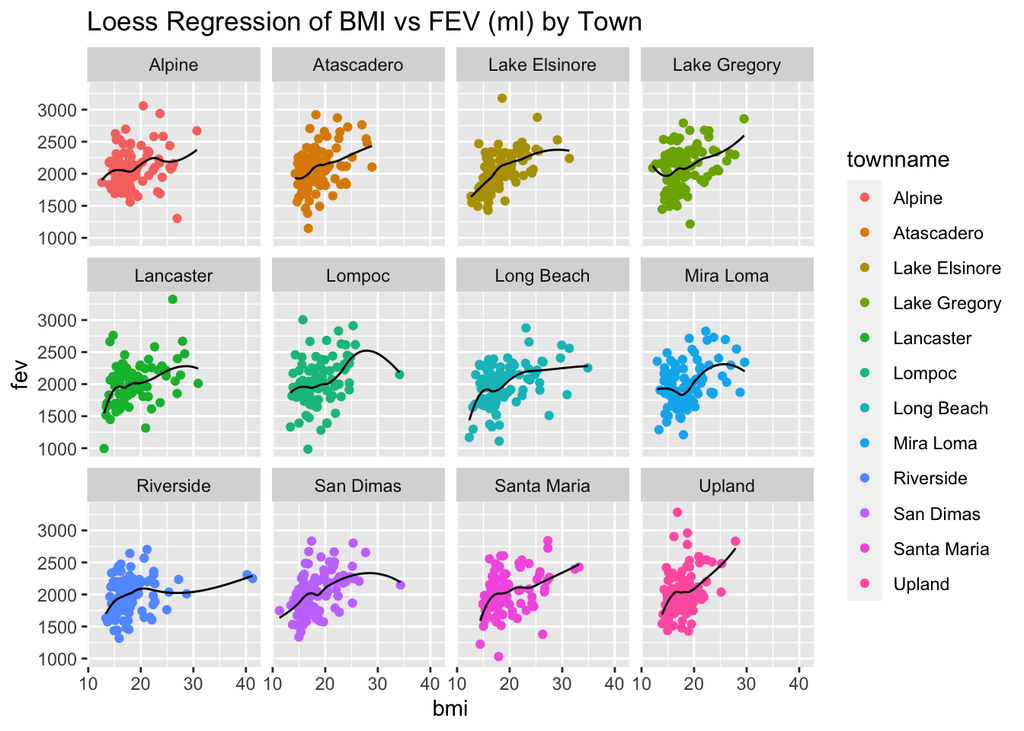

```r
#1 - BMI vs FEV
ggplot(data=chs, aes(bmi, fev, col=townname)) +
  geom_point(mapping = aes(x = bmi, y = fev, color=townname)) + stat_smooth(method='loess', col='black', size=0.5, se=F)+
  facet_wrap(~ townname, nrow = 3) + ggtitle("Loess Regression of BMI vs FEV (ml) by Town")
```

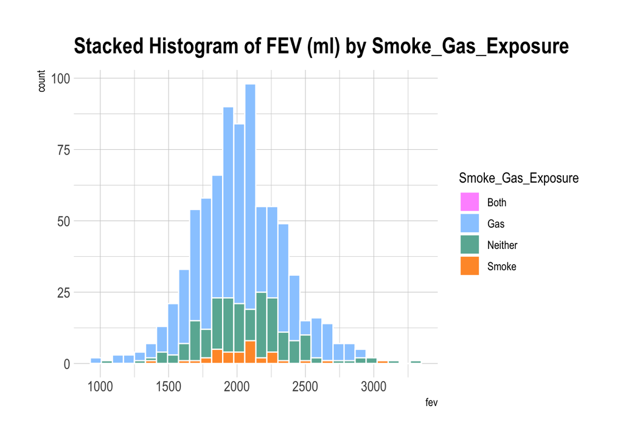

```r
#2 - Smoke_gas_exp vs FEV
chs%>%
ggplot( aes(x=fev, fill=smoke_gas_exposure)) +
    geom_histogram( color="white", position = 'identity') +
    scale_fill_manual(values=c("#FF99FF", "#99ccFF", "#69b3a2", "#FF9933")) +
    theme_ipsum() +
    labs(fill="Smoke_Gas_Exposure") + ggtitle("Stacked Histogram of FEV (ml) by Smoke_Gas_Exposure")
```

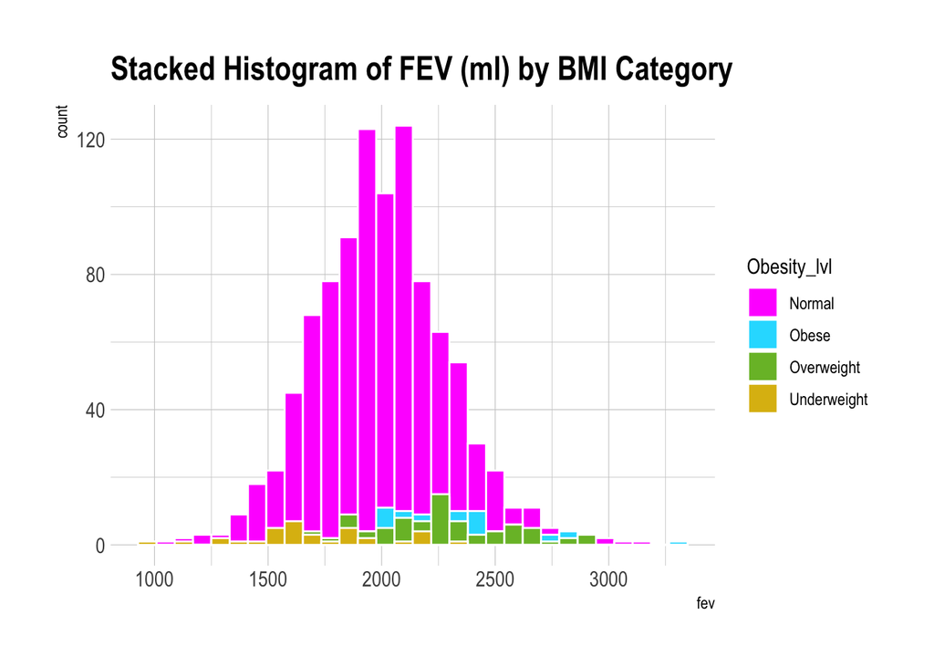

```r
chs%>%
ggplot( aes(x=fev, fill=obesity_lvl)) +
    geom_histogram( color="white", position = 'identity') +
    scale_fill_manual(values=c("#FF33FF", "#22ddFF", "#79bc32", "#DDbb11")) +
    theme_ipsum() +
    labs(fill="Obesity_lvl") + ggtitle("Stacked Histogram of FEV (ml) by BMI Category")
```